# Case Study: EDA program

## ----- Configuration -----

```python
# Common imports
import os
import numpy as np
# to make this notebook's output stable across runs
np.random.seed(42)


# To support both python 2 and python 3
from __future__ import division, print_function, unicode_literals


# To plot pretty figures
%matplotlib inline
import matplotlib
import matplotlib.pyplot as plt
plt.rcParams['axes.labelsize'] = 14
plt.rcParams['xtick.labelsize'] = 12
plt.rcParams['ytick.labelsize'] = 12
import seaborn as sns
#sns.set_style("whitegrid")
#sns.set_context("poster")


# Where to save the figures
PROJECT_ROOT_DIR = "."
IMAGES_PATH = os.path.join(PROJECT_ROOT_DIR, "images")

def save_fig(fig_id, tight_layout=True, fig_extension="png", resolution=300):
    path = os.path.join(IMAGES_PATH, fig_id + "." + fig_extension)
    print("Saving figure", fig_id)
    if tight_layout:
        plt.tight_layout()
    plt.savefig(path, format=fig_extension, dpi=resolution)

# Ignore useless warnings
import warnings
#warnings.filterwarnings(action="ignore", module="scipy", message="^internal gelsd")
warnings.filterwarnings('ignore')


# Python model  package needed

import pandas as pd
from random import randint
import math
from scipy import stats, integrate
import time
from sklearn.externals import joblib

# model
from sklearn.linear_model import SGDClassifier, LogisticRegression
from sklearn.svm import SVC, LinearSVC
from sklearn.tree import DecisionTreeClassifier
from sklearn.ensemble import RandomForestClassifier, AdaBoostClassifier, ExtraTreesClassifier,VotingClassifier
from sklearn.neighbors import KNeighborsClassifier
import xgboost as xgb

# evaluation
from sklearn.model_selection import train_test_split,cross_val_predict,cross_val_score, GridSearchCV,RandomizedSearchCV,cross_validate, KFold
from sklearn.preprocessing import StandardScaler,MinMaxScaler
from sklearn.metrics import confusion_matrix,classification_report,f1_score,recall_score,precision_score,accuracy_score,precision_recall_curve,roc_curve,roc_auc_score
#from sklearn import metrics
import scikitplot as skplt
```

## ----- User defined functions -----

```python
#check data summary
def summary_stat(df):
    pd.set_option('display.float_format',lambda x : '%.2f'% x)
    print("\n-------------Columns in the data--------------------------------")
    print (df.columns.tolist())
    print("\n-------------Variable Types-------------------------------")
    print  (df.info())
    print("\n---------------------------------------------")
    print("Number of columns are {} and Number of rows are {} respectively.".format(df.shape[1], df.shape[0]))
    print("Number of Nulls - {}.".format(df.isnull().sum().sum()))
    nans=df.iloc[df.index[df.isnull().all(1)]]
    print("All rows are Nulls -{}.".format(len(nans)))

def pct_miss(data):
    columns = data.columns
    tot=len(data)
    percent_missing= data.isnull().sum() * 100 / len(data)
    missing_count=data.isnull().sum()
    missdf = pd.DataFrame({'column_name': columns,'miss_count': missing_count,'pct_missing': percent_missing,'total counts':tot})
    missdf.sort_values('miss_count',ascending=False, inplace=True)
    return missdf.to_csv('missing_pct.csv')
    #return missdf

# level of categorical variables
def char_level(chardf):
    columns = chardf.columns
    levels=chardf.nunique()
    char= pd.DataFrame({'column_name': columns,'levels': levels})
    char.sort_values('levels',ascending=False, inplace=True)
    return char

# check num variable distribution
def num_distr(numdf):
# check the distribution of numvars  and save as pandas dataframe,  transpose the output
    pd.set_option('display.float_format',lambda x : '%.2f'% x)
    stats = numdf.describe().transpose()
    stats['miss_count']= numdf.shape[0] - stats['count'].astype(int)
    stats['missing_pct'] =( numdf.shape[0] - stats['count'].astype(int))/numdf.shape[0]
    stats['var']=stats.index
       # output to a csv file
    stats.to_csv('num_dist.csv')
    return stats

# target distribution
def target_rate(df,y):
    tot_tag_rate = df[y].sum()*1.0/df.shape[0]
    return   tot_tag_rate
```

```python
# EDA chart
def univariate_numvar(df, gr,xvar,  yvar=None,dec=None):
    x = df[xvar]

    # print (' Variable :{}'.format(x))
    #print (' Number of missing :{}'.format(x.isna().sum()))

    f, ax1 = plt.subplots(figsize=(10,10))


    # quatile bining
    srs, binEdges = pd.qcut(x, gr, labels=False, retbins=True,duplicates='drop')
    ax1.bar(range(len(x.groupby(srs).count().index)), x.groupby(srs).count() )



    # legend
    if np.median(np.array(binEdges)) > 100:
        rangeformat = '%.f - %.f'
    else:
        rangeformat = '%.2f - %.2f'
    textstr = '\n'.join([('Bin%d: ' + rangeformat) % (i, binEdges[i], binEdges[i+1]) for i in range(len(binEdges)-1)])


    ax1.text(1.15, 0.98, textstr, transform=ax1.transAxes, fontsize=14, verticalalignment='top')

    # title
    ax1.set_xlabel(' %s' %(xvar))
    ax1.set_title('Plot of Variable: %s ' % (xvar), fontsize=16)
    ax1.set_ylabel('Counts')


    # If target is provided, plotted on the same chart
    if yvar:
        y = df[yvar]
        # second y axis
        ax2 = ax1.twinx()
        ax2.grid(False)
        plt.plot(y.groupby(srs).mean().index, y.groupby(srs).mean(), 'yo-' ,label=yvar)

        if dec:
            p=df[dec]
            plt.plot(p.groupby(srs).mean().index, p.groupby(srs).mean(), color='g',label=dec)
        plt.legend(loc='right')


    plt.show()
    #pp.savefig()
```

```python
def catplot(df,x,y,  plot):
    print (' Variable :{}'.format(x))
    cnts=df[x].value_counts()

    cnt_pct=df[x].value_counts()/df[x].count()
    avgtg=df.groupby([x])[y].mean()
    cy_df=pd.DataFrame({'Counts': cnts,'counts_pct':cnt_pct,'Avg_Target_Rate':avgtg })
    cy_df[x]=cy_df.index
    cy_df=cy_df.sort_index(axis=0, ascending=True)


    display(cy_df)


    if plot:


        plt.figure(figsize=(10, 10))
        plt.clf()

        sns.barplot(x, 'Counts',data=cy_df, alpha=1,color='b')


        plt.title('Plot of Variable :{}'.format(x),fontsize=16)
        plt.ylabel('Counts', fontsize=16)
        plt.xlabel(x, fontsize=16)
        plt.xticks(rotation='vertical')
        plt.grid(False)

        # line chart
        ax2 = plt.twinx()  # instantiate a second axes that shares the same x-axis
        ax2.grid(False)
        ax2.plot(cy_df[['Avg_Target_Rate']].values, linestyle='-', marker='o', linewidth=2.0,color='y')
        ax2.set_ylabel('Avg_Target_Rate')


        plt.show()
        #pp.savefig()
    return cy_df
```

## ----- Get the data -----

```python
# Import data
df= pd.read_csv('./data/bank/bank.csv', engine='python',index_col=False, header=None, delimiter='\;').replace('"','', regex=True)
# set up first row as column name
df.columns = df.iloc[0]
# remove first row which contains header
df = df.drop(index=0).reset_index(drop=True)
# drop last blank column
df=df.iloc[:,0:-1]
# what data looks like
df.tail(5)
```

|  | age | job | marital | education | default | balance | housing | loan | contact | day | month | duration | campaign | pdays | previous | poutcome | y |
| --- | --- | --- | --- | --- | --- | --- | --- | --- | --- | --- | --- | --- | --- | --- | --- | --- | --- |
| 42595 | 28 | unemployed | single | NULL | no | 0 | no | NULL | cellular | 6 | feb | 15 | 9 | -1 | 0 | unknown | no |
| 42596 | NULL | blue-collar | married | NULL | no | 175 | yes | NULL | cellular | 4 | feb | 430 | 2 | 272 | 3 | other | no |
| 42597 | NULL | blue-collar | married | NULL | no | 4 | yes | NULL | cellular | 8 | jul | 173 | 1 | -1 | 0 | unknown | no |
| 42598 | 43 | management | married | NULL | no | 704 | no | NULL | cellular | 18 | jul | 116 | 1 | -1 | 0 | unknown | no |
| 42599 | 49 | management | single | NULL | no | -18 | yes | NULL | cellular | 11 | may | 217 | 3 | 264 | 4 | failure | no |

## ----- Data Summary -----

```python
# variable name and type check
summary_stat(df)
```

```
-------------Columns in the data--------------------------------
['age', 'job', 'marital', 'education', 'default', 'balance', 'housing', 'loan', 'contact', 'day', 'month', 'duration', 'campaign', 'pdays', 'previous', 'poutcome', 'y']

-------------Variable Types-------------------------------
<class 'pandas.core.frame.DataFrame'>
RangeIndex: 42600 entries, 0 to 42599
Data columns (total 17 columns):
age          42600 non-null object
job          42600 non-null object
marital      42600 non-null object
education    42600 non-null object
default      42600 non-null object
balance      42600 non-null object
housing      42600 non-null object
loan         42600 non-null object
contact      42600 non-null object
day          42600 non-null object
month        42600 non-null object
duration     42600 non-null object
campaign     42600 non-null object
pdays        42600 non-null object
previous     42600 non-null object
poutcome     42600 non-null object
y            42600 non-null object
dtypes: object(17)
memory usage: 5.5+ MB
None

---------------------------------------------
Number of columns are 17 and Number of rows are 42600 respectively.
Number of Nulls - 0.
All rows are Nulls -0.
```

## ----- EDA -----

### Y distribution

```
Saving figure target distribution
```

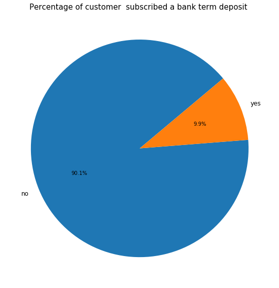

```python
## target distribution pre-check
# Data to plot
from pylab import rcParams
sizes = df['y'].value_counts(sort = True)
colors = ["gray","green"]
rcParams['figure.figsize'] = 8,8
labels = (df['y'].unique())
#Plot
plt.pie(sizes,  labels=labels,
        autopct='%1.1f%%',  startangle=400,)
plt.title('Percentage of customer  subscribed a bank term deposit ',fontsize=15)
#plt.show()
save_fig("target distribution")
```

** Note:

1. All the input variables are object when read in , and missing value was code as 'NULL'. We need convert variable format first.
2. Target distribution : 9.9% of customer will subscribe 90.1% of customer will not subscribe not a highly imbalanced data - emsemble method can improve and maybe choose Precision and Recall score to evaluate model and we need reduce the false negative ( target on the right customer ) , so high recall

### Look at Xs

```python
# independent variable list
var=df.iloc[:,0:-1].columns.tolist()
target='y'
# numerical var datasets:
num_var=['age','balance','day','duration', 'campaign', 'pdays', 'previous']
# convert object to num for numerical variables
num_df = df[num_var].apply(pd.to_numeric, errors='coerce')
# char var datasets :
char_var=[x for x in var if not x in num_var]
char_df=df[char_var]
```

```python
# check missing% for char vars
char_df2=char_df.replace('NULL',np.nan)
pct_miss(char_df2)
```

```python
# combine datasets
df2=pd.concat([num_df,char_df],axis=1)
# convert target to numerical
df2['y']=np.where(df['y']=='yes', 1,0)
df2.to_csv('bank1.csv')
df2.tail(5)
```

|  | age | balance | day | duration | campaign | pdays | previous | job | marital | education | default | housing | loan | contact | month | poutcome | y |
| --- | --- | --- | --- | --- | --- | --- | --- | --- | --- | --- | --- | --- | --- | --- | --- | --- | --- |
| 42595 | 28.00 | 0 | 6 | 15 | 9 | -1 | 0 | unemployed | single | NULL | no | no | NULL | cellular | feb | unknown | 0 |
| 42596 | nan | 175 | 4 | 430 | 2 | 272 | 3 | blue-collar | married | NULL | no | yes | NULL | cellular | feb | other | 0 |
| 42597 | nan | 4 | 8 | 173 | 1 | -1 | 0 | blue-collar | married | NULL | no | yes | NULL | cellular | jul | unknown | 0 |
| 42598 | 43.00 | 704 | 18 | 116 | 1 | -1 | 0 | management | married | NULL | no | no | NULL | cellular | jul | unknown | 0 |
| 42599 | 49.00 | -18 | 11 | 217 | 3 | 264 | 4 | management | single | NULL | no | yes | NULL | cellular | may | failure | 0 |

```python
df2['y'].value_counts()
```

```
0    38400
1     4200
Name: y, dtype: int64
```